# Minería de Datos: Selección y Preparación del Dataset (Heart Disease UCI)

Manuel Membrilla Martinez

Noviembre 2025

# 1 Planteamiento del problema y selección del dataset

# 2 Análisis y desarrollo

## 2.1 Planteamiento del problema

El problema se va a centrar en un analisis de datos medicos relacionadas con enfermedades cardiacas con el fin de reconocer patrones asociadas a la existencia de riesgos cardiovasculares. Se utilizara el conjunto de datos de Heart Disease UCI. Al pertenecer a un ambito sanitario, este estudio es totalmente necesario para preveer el riesgo de los pacientes y reducir tanto complicaciones medicas, como costes medicos.

### 2.1.1 Objetivos analíticos

Objetivo 1. Identificar que factores clinicos estan más relacionados con la presencia de enfermedades cardiacas.

Objetivo 2. Analisis de variables externas como la edad, tipo de dolor, frecuencia cardiaca, etc.

Objetivo 3. Evaluacion de relacion entre las variables mediante correlaciones y diagramas de dispersion

Objetivo 4. Aplicacion de tecnicas de normalizacion y discretizacion

Objetivo 5. Preparacion de los datos para las tecnicas supervisadas y no supervisadas

Objetivo 6. Aplicar PCA para estudiar la estructura del dataset.

### 2.1.2 Metodología

*Compresion de los datos*

Carga del dataset, revisar la estructura y las vairables. Ademas se realizara un analisis exploratorio univariante y bivariante.

*Transformacion de los datos*

Normalizacion para distribuciones especificas Normalizacion minimo y maximo Transformacion logaritmica para los sesgos Discretizacion mediante el metodo de particion en intervalos con misma amplitud

*Seleccion de caracteristicas*

Variables con varianzas que se acerquen a 0. Correlacion entre variables. PCA para identicias componentes relevantes.

*Reduccion de la dimensionalidad*

Se realizara mediante PCA con la seleccion de componentes con mas de 90% de varianza aproximadamente.

### 2.1.3 Minería de datos

Se realizara un analisis univariante y multivariante, en cuanto a las caracteristicas, normalizacion, transformaciones logaritmicas y discretizacion. Diagramas de dispercion y PCA como la tecnica principal del analisis.

### 2.1.4 Evaluación e interpretación del modelo

Se utilizara el analisis de componentes princpales que nos permitira trabajar con nuevas caracteristicas entre si, este sistema estara mejor adaptado para la distribucion de datos.

La calidad de representacion de las variables en el mapas se denomica cos2 (conseno cuadrado)

## 2.2 Selección del juego de datos

En el enunciado se nos indica que el juego de datos tiene que tener capacidad para aplicar algoritmo supervisados y no supervisados.

### 2.2.1 Justificación de la elección

La seleccion de los datos no ha sido tan facil realmente, ya que tenemos que evaluar las variables de cada uno y si realmente se iban a poder trabajar con esos datos. Aunque mi conocimiento en el ambito medico no es del todo el mejor, gracias al apoyo que nos ofrece este asignatura al realizar consultas a la IA en cuanto a terminologias que desconozco, considero que es una buena eleccion para trabajar todos los elementos que se solicitan en esta practica como el tamaño y estrucutura, ademas de ser potencialmente adecuado para el modelo supervisado y no supervisado.

## 2.3 Análisis exploratorio de datos

El dataset provienente para estudio: https://www.kaggle.com/datasets/fedesoriano/heart-failure-prediction/

```r
# Las librerias que se van utilizar
if (!require(readr)) install.packages('readr');
```

```r
library(readr)
if (!require('ggplot2')) install.packages('ggplot2'); library('ggplot2')
if (!require('dplyr')) install.packages('dplyr'); library('dplyr')
path ='heart.csv'
heart_df <- read.csv(path, row.names=NULL)
structure = str(heart_df)
```

```
## 'data.frame':    918 obs. of  12 variables:
##  $ Age           : int  40 49 37 48 54 39 45 54 37 48 ...
##  $ Sex           : chr  "M" "F" "M" "F" ...
##  $ ChestPainType : chr  "ATA" "NAP" "ATA" "ASY" ...
##  $ RestingBP     : int  140 160 130 138 150 120 130 110 140 120 ...
##  $ Cholesterol   : int  289 180 283 214 195 339 237 208 207 284 ...
##  $ FastingBS     : int  0 0 0 0 0 0 0 0 0 0 ...
##  $ RestingECG    : chr  "Normal" "Normal" "ST" "Normal" ...
##  $ MaxHR         : int  172 156 98 108 122 170 170 142 130 120 ...
##  $ ExerciseAngina: chr  "N" "N" "N" "Y" ...
##  $ Oldpeak       : num  0 1 0 1.5 0 0 0 0 1.5 0 ...
##  $ ST_Slope      : chr  "Up" "Flat" "Up" "Flat" ...
##  $ HeartDisease  : int  0 1 0 1 0 0 0 0 1 0 ...
```

EL dataset presenta 918 observaciones, mas de 5 variables numericas(Age, RestingBP, Chrolesterol, MaxHr, Oldpeak) y mas de 2 variables categoricas(Sex, ChestPainType, RestingECG, ExerciseANgina, ST_Slope), ademas de una variable binaria que en este caso es HeartDisease. Pro lor que entraria dentro de lo permitido por el enunciado. Ademas nos permitira en un futuro aplicar tecnicas supervisadas y no supervisados

### 2.3.2 Análisis estadístico de variables

```r
#summary(heart_df)
#
summary(heart_df[c("Age","Cholesterol","RestingBP","MaxHR","Oldpeak")])
```

```
##       Age         Cholesterol      RestingBP         MaxHR
##  Min.   :28.00   Min.   :  0.0   Min.   :  0.0   Min.   : 60.0
##  1st Qu.:47.00   1st Qu.:173.2   1st Qu.:120.0   1st Qu.:120.0
##  Median :54.00   Median :223.0   Median :130.0   Median :138.0
##  Mean   :53.51   Mean   :198.8   Mean   :132.4   Mean   :136.8
##  3rd Qu.:60.00   3rd Qu.:267.0   3rd Qu.:140.0   3rd Qu.:156.0
##  Max.   :77.00   Max.   :603.0   Max.   :200.0   Max.   :202.0
##     Oldpeak
##  Min.   :-2.6000
##  1st Qu.: 0.0000
##  Median : 0.6000
##  Mean   : 0.8874
##  3rd Qu.: 1.5000
##  Max.   : 6.2000
```

Obtenemos una edad minima de 28 años y un maximo de 77 años aproximadamente y con una mediana que lo situa en 54 años de edad, podemos oberserva que la mayoria de los pacientes son adultos.

La presion arterial (ResingBP), el rango se situa entre 0 y 200, no encontramos lo mismo con registros incorrectos o valores atipicos, la mediana con 130 mmHg nos indica que los pacientes por lo general presentan hipertension.

### 2.3.3 Análisis de variables categóricas

```r
heart_df$Sex <- factor(heart_df$Sex, levels = c(0,1), labels = c("Mujer","Hombre"))
heart_df$HeartDisease <- factor(heart_df$HeartDisease, levels = c(0,1),
labels = c("No","Sí"))

table(heart_df$Sex)
```

```
##
##  Mujer Hombre
##      0      0
```

```r
prop.table(table(heart_df$Sex))
```

```
##
##  Mujer Hombre
##
```

```r
table(heart_df$HeartDisease)
```

```
##
##  No  Sí
## 410 508
```

```r
prop.table(table(heart_df$HeartDisease))
```

```
##
##        No        Sí
## 0.4466231 0.5533769
```

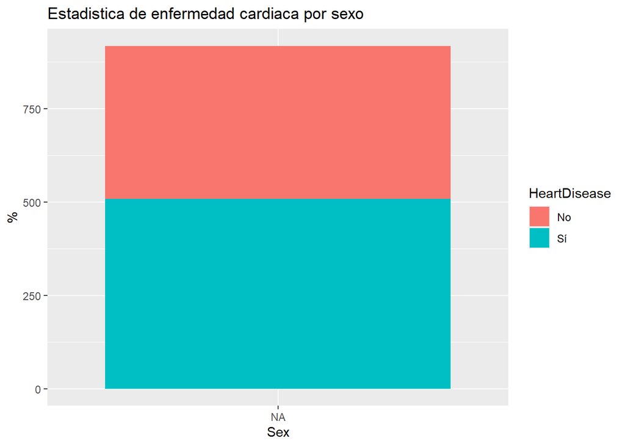

```r
ggplot(heart_df, aes(x = Sex, fill = HeartDisease)) + geom_bar() +ylab("%") +ggtitle("Estadistica de enfermedad cardiaca por sexo")
```

## 2.4 Limpieza y acondicionamiento de datos

### 2.4.1 Valores no disponibles

```r
faltantes_heart_df <- sort(colSums(is.na(heart_df)), decreasing=TRUE)
faltantes_heart_df
```

```
##            Sex            Age  ChestPainType      RestingBP    Cholesterol
##            918              0              0              0              0
##      FastingBS     RestingECG          MaxHR ExerciseAngina        Oldpeak
##              0              0              0              0              0
##       ST_Slope   HeartDisease
##              0              0
```

### 2.4.2 Tareas de limpieza

```r
heart_df_clean <-heart_df %>%
mutate_if(is.character,as.factor) %>%
mutate_if(is.logical, as.factor)

str(heart_df_clean)
```

```
## 'data.frame':    918 obs. of  12 variables:
##  $ Age           : int  40 49 37 48 54 39 45 54 37 48 ...
##  $ Sex           : Factor w/ 2 levels "Mujer","Hombre": NA NA NA NA NA NA NA NA NA NA ...
##  $ ChestPainType : Factor w/ 4 levels "ASY","ATA","NAP",..: 2 3 2 1 3 3 2 2 1 2 ...
##  $ RestingBP     : int  140 160 130 138 150 120 130 110 140 120 ...
##  $ Cholesterol   : int  289 180 283 214 195 339 237 208 207 284 ...
##  $ FastingBS     : int  0 0 0 0 0 0 0 0 0 0 ...
##  $ RestingECG    : Factor w/ 3 levels "LVH","Normal",..: 2 2 3 2 2 2 2 2 2 2 ...
##  $ MaxHR         : int  172 156 98 108 122 170 170 142 130 120 ...
##  $ ExerciseAngina: Factor w/ 2 levels "N","Y": 1 1 1 2 1 1 1 1 2 1 ...
##  $ Oldpeak       : num  0 1 0 1.5 0 0 0 0 1.5 0 ...
##  $ ST_Slope      : Factor w/ 3 levels "Down","Flat",..: 3 2 3 2 3 3 3 3 2 3 ...
##  $ HeartDisease  : Factor w/ 2 levels "No","Sí": 1 2 1 2 1 1 1 1 2 1 ...
```

### 2.4.3 Valores imposibles

```r
heart_df_clean$Cholesterol[heart_df_clean$Cholesterol==0] <- NA
heart_df_clean$RestingBP[heart_df_clean$RestingBP==0] <- NA

colSums(is.na(heart_df_clean))
```

```
##            Age            Sex  ChestPainType      RestingBP    Cholesterol
##              0            918              0              1            172
##      FastingBS     RestingECG          MaxHR ExerciseAngina        Oldpeak
##              0              0              0              0              0
##       ST_Slope   HeartDisease
##              0              0
```

## 2.5 Análisis univariante y bivariante

### 2.5.1 Histograma de edad (Age)

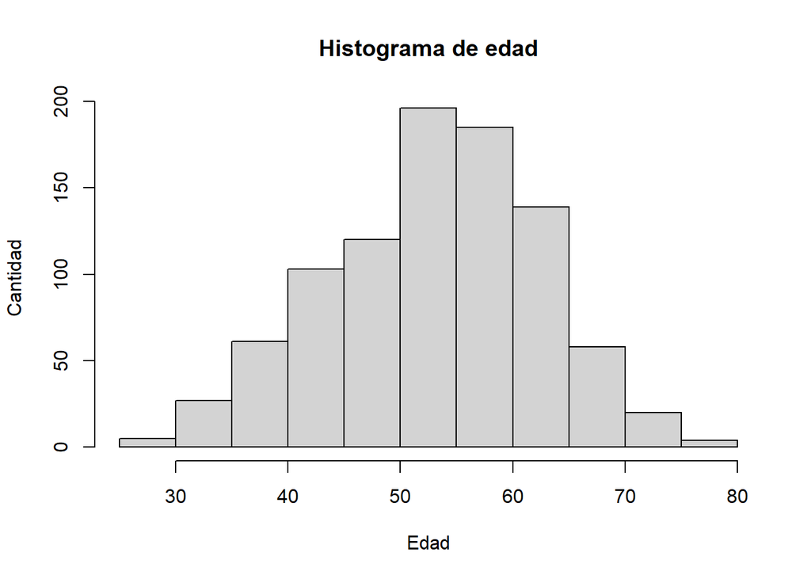

```r
hist(heart_df$Age,main="Histograma de edad", xlab="Edad", ylab="Cantidad")
```

Observamos una curva que va incrementando de los 30 hasta 50-55, esto es un perfil coherente de la poblacion de riesgo para la enfermedad cardiaca.

### 2.5.2 Histograma de colesterol

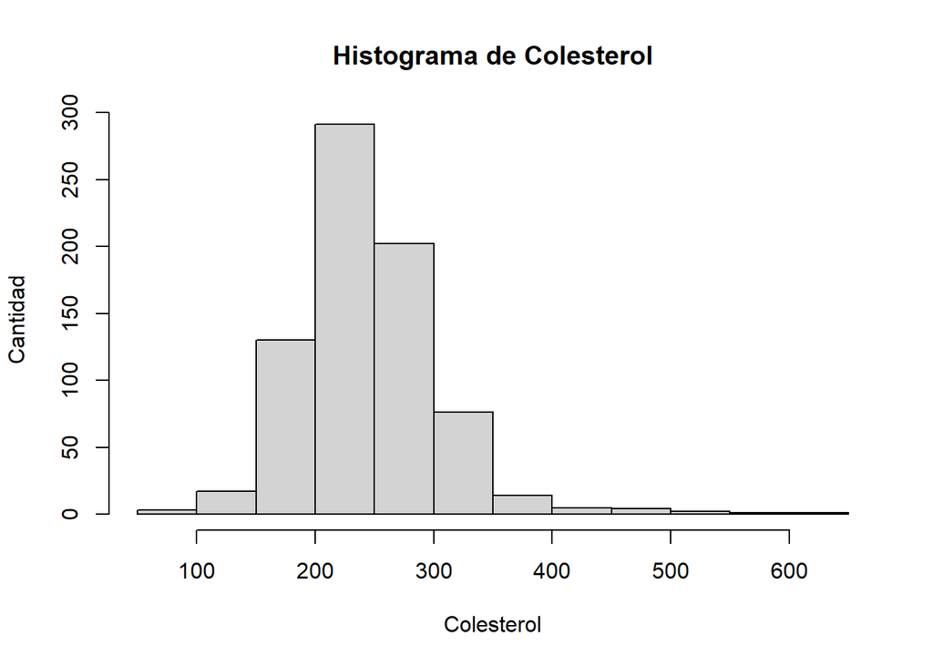

```r
hist(heart_df_clean$Cholesterol,main="Histograma de Colesterol", xlab="Colesterol", ylab="Cantidad")
```

Observamos como el histograma del colesterol con una alta concentracion en pacientes en valores de colesterol moderados y una cola larga que se extiende a valores elevados. Algunos de estos pacientes podria corresponder a hipercolesterolemia severa o errores de registro. Ademas de los valores en 0 que sugiere valores anormalos o mal codificados, que ya se arreglo en la fase de limpieza.

### 2.5.3 Histograma de presión arterial en reposo

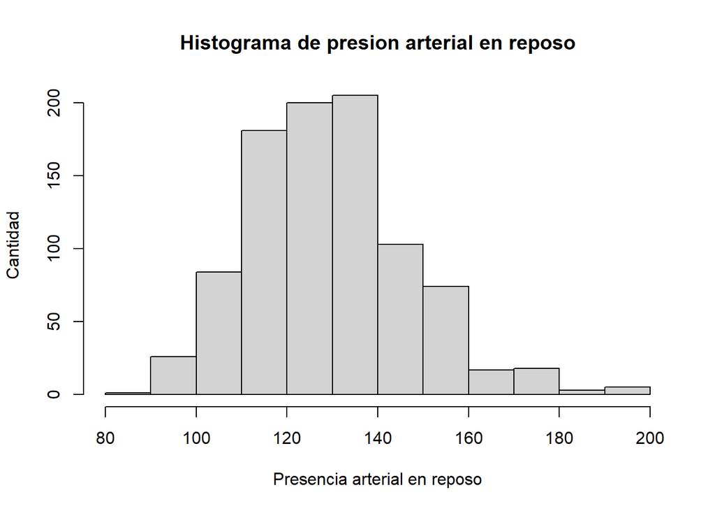

```r
hist(heart_df_clean$RestingBP,main="Histograma de presion arterial en reposo", xlab="Presencia arterial en reposo", ylab="Cantidad")
```

Se observa que la mayoria de los pacientes presentan valores entre los 120-1240 mmHg, esto normalemente es compatible con situaciones de hipertension leve.

### 2.5.4 Histograma de frecuencia cardíaca máxima

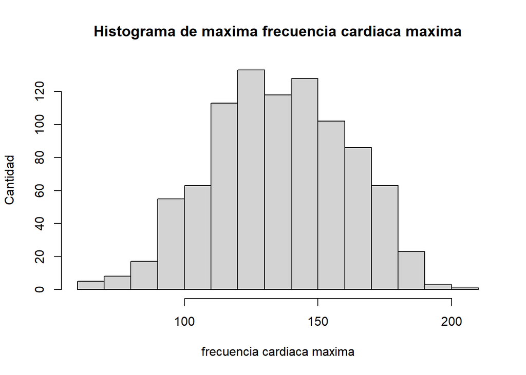

```r
hist(heart_df$MaxHR,main="Histograma de maxima frecuencia cardiaca maxima", xlab="frecuencia cardiaca maxima", ylab="Cantidad")
```

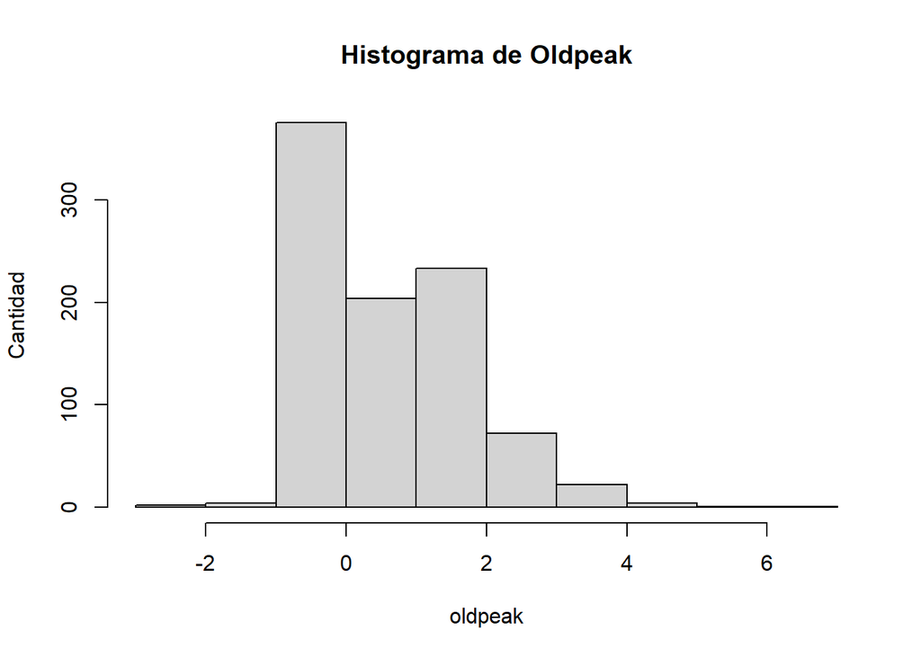

```r
hist(heart_df$Oldpeak,main="Histograma de Oldpeak", xlab="oldpeak", ylab="Cantidad")
```

La mayoria de los pacientes presentan valores cercanos a cero, mientras que una minoria tienen valores altos en la depresion del segmento ST. Esto es coherente desde una parte clinica ya que solo una parte de los pacientes presentan alteraciones significativas en el electro.

### 2.5.5 Dispersión: Edad vs. Colesterol

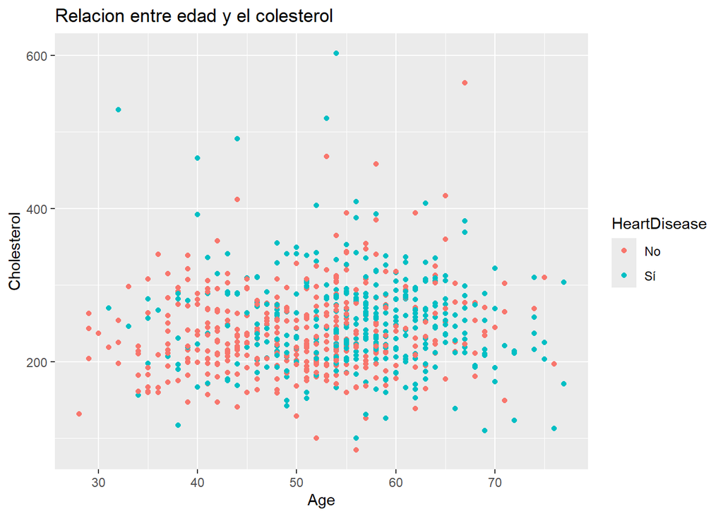

```r
ggplot(heart_df_clean, aes(x=Age, y=Cholesterol, color=HeartDisease))+geom_point(na.rm=TRUE)+ggtitle("Relacion entre edad y el colesterol")
```

Ademas podemos observar mediante los puntos, si estas personas padecen de alguna enfermedad cardiaca.

### 2.5.6 Dispersión: Edad vs. Frecuencia cardíaca máxima

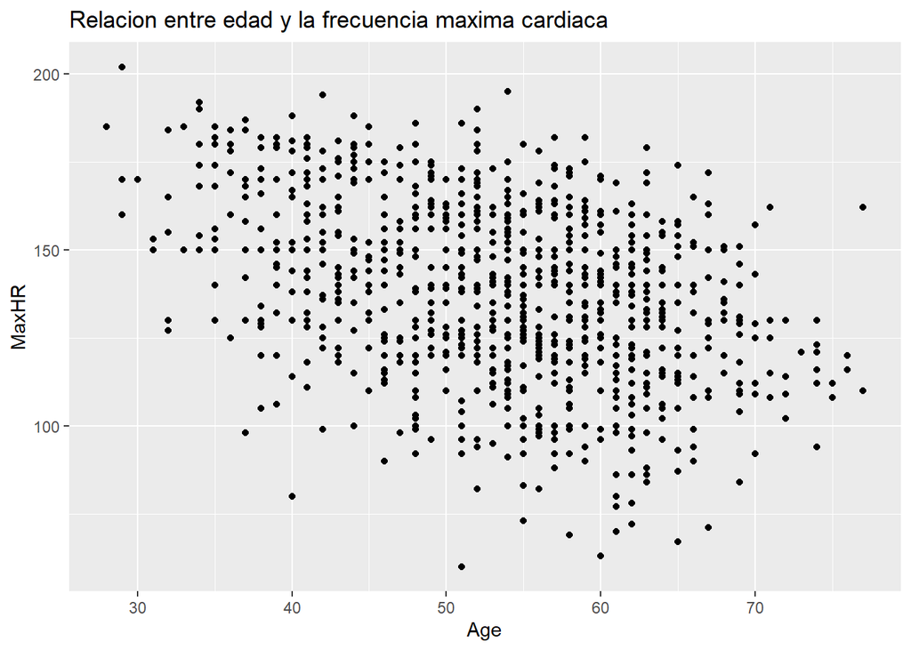

```r
ggplot(heart_df, aes(x=Age, y=MaxHR))+geom_point()+ggtitle("Relacion entre edad y la frecuencia maxima cardiaca")
```

### 2.5.7 Dispersión: Presión arterial vs. Colesterol

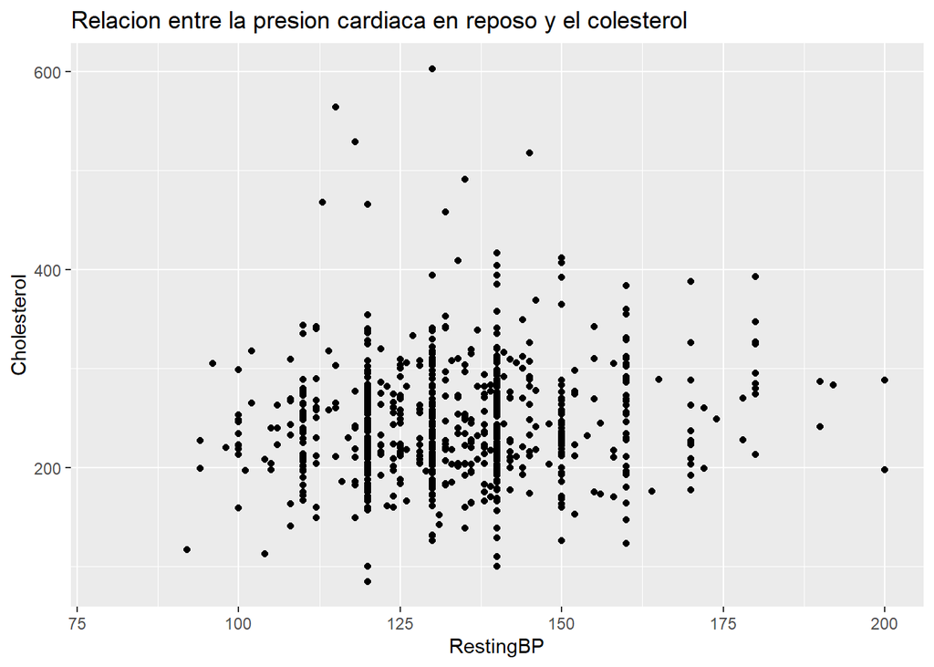

```r
ggplot(heart_df_clean, aes(x=RestingBP, y=Cholesterol))+geom_point(na.rm=TRUE)+ggtitle("Relacion entre la presion cardiaca en reposo y el colesterol")
```

### 2.5.8 Dispersión: Colesterol vs. Oldpeak

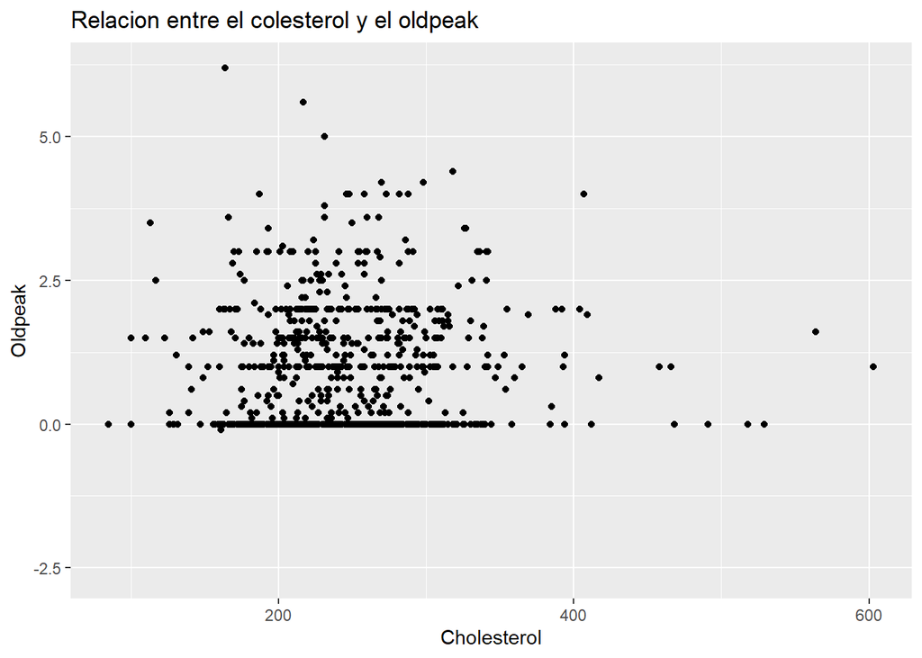

```r
ggplot(heart_df_clean, aes(x=Cholesterol, y=Oldpeak))+geom_point(na.rm=TRUE)+ggtitle("Relacion entre el colesterol y el oldpeak")
```

### 2.5.9 Test de correlación entre variables

Seleccion de variables numericas

```r
variables_numericas <- heart_df %>% select(Age, Cholesterol, RestingBP, MaxHR, Oldpeak)
```

Matriz de correlacion

```r
matriz_correlacion <- cor(variables_numericas)
matriz_correlacion
```

```
##                     Age Cholesterol  RestingBP      MaxHR     Oldpeak
## Age          1.00000000 -0.09528177  0.2543994 -0.3820447  0.25861154
## Cholesterol -0.09528177  1.00000000  0.1008929  0.2357924  0.05014811
## RestingBP    0.25439936  0.10089294  1.0000000 -0.1121350  0.16480304
## MaxHR       -0.38204468  0.23579240 -0.1121350  1.0000000 -0.16069055
## Oldpeak      0.25861154  0.05014811  0.1648030 -0.1606906  1.00000000
```

## 2.6 Transformación de datos

### 2.6.1 Normalización min-max

```r
normalize <- function(x) {
(x - min(x, na.rm = TRUE)) / (max(x, na.rm = TRUE) - min(x, na.rm = TRUE))
}

heart_df_norm <- heart_df_clean
heart_df_norm[, sapply(heart_df_norm, is.numeric)] <-
lapply(heart_df_norm[, sapply(heart_df_norm, is.numeric)], normalize)

head(heart_df_norm)
```

```
##         Age  Sex ChestPainType RestingBP Cholesterol FastingBS RestingECG
## 1 0.2448980 <NA>           ATA 0.5000000   0.3938224         0     Normal
## 2 0.4285714 <NA>           NAP 0.6666667   0.1833977         0     Normal
## 3 0.1836735 <NA>           ATA 0.4166667   0.3822394         0         ST
## 4 0.4081633 <NA>           ASY 0.4833333   0.2490347         0     Normal
## 5 0.5306122 <NA>           NAP 0.5833333   0.2123552         0     Normal
## 6 0.2244898 <NA>           NAP 0.3333333   0.4903475         0     Normal
##       MaxHR ExerciseAngina   Oldpeak ST_Slope HeartDisease
## 1 0.7887324              N 0.2954545       Up           No
## 2 0.6760563              N 0.4090909     Flat           Sí
## 3 0.2676056              N 0.2954545       Up           No
## 4 0.3380282              Y 0.4659091     Flat           Sí
## 5 0.4366197              N 0.2954545       Up           No
## 6 0.7746479              N 0.2954545       Up           No
```

Se ha aplicado una normalizacion max-min para todas las variables numericas, transformando cada variable en variables entre 0 y 1, mantiniendo la forma pero ajustando la escala. Esto se realiza con el fin de evitar rangos diferentes y tenga mas afluencia.

## 2.7 Métodos de discretización

### 2.7.1 Discretización de la variable HeartDisease

En este caso la variable ya es binaria, el cual 0 es que no existe enfermedad cardiaca y 1 si existe enfermedad cardiaca por lo tanto no hace falta discretizacion.

La distribucion seria la siguiente

```r
table(heart_df$HeartDisease)
```

```
##
##  No  Sí
## 410 508
```

```r
prop.table(table(heart_df$HeartDisease))
```

```
##
##        No        Sí
## 0.4466231 0.5533769
```

### 2.7.2 Partición en intervalos de igual amplitud

Vamos a discretizar la variable Age en tres intervalos, de forma que quedaria edad baja, edad media y edad alta. Para ello se realiza un cut.

```r
heart_df$Age_part <- cut(heart_df$Age, breaks=3, labels= c("Edad baja", "Edad media", "Edad alta"))
table(heart_df$Age_part)
```

```
##
##  Edad baja Edad media  Edad alta
##        178        519        221
```

Este metodo no garantiza que exista el mismo numero de observaciones para cada uno de los intervalos.

## 2.8 Análisis de Componentes Principales (PCA)

### 2.8.1 Aplicación del PCA

Mediante prcomp()

```r
pca_heart_df <- heart_df_norm %>%
select(Age, RestingBP, Cholesterol, MaxHR, Oldpeak) %>%
na.omit()

pca_res <- prcomp(pca_heart_df, center = TRUE, scale. = TRUE)

summary(pca_res)
```

```
## Importance of components:
##                           PC1    PC2    PC3    PC4    PC5
## Standard deviation     1.3367 1.0072 0.9243 0.8689 0.7678
## Proportion of Variance 0.3573 0.2029 0.1709 0.1510 0.1179
## Cumulative Proportion  0.3573 0.5602 0.7311 0.8821 1.0000
```

### 2.8.2 Scree plot

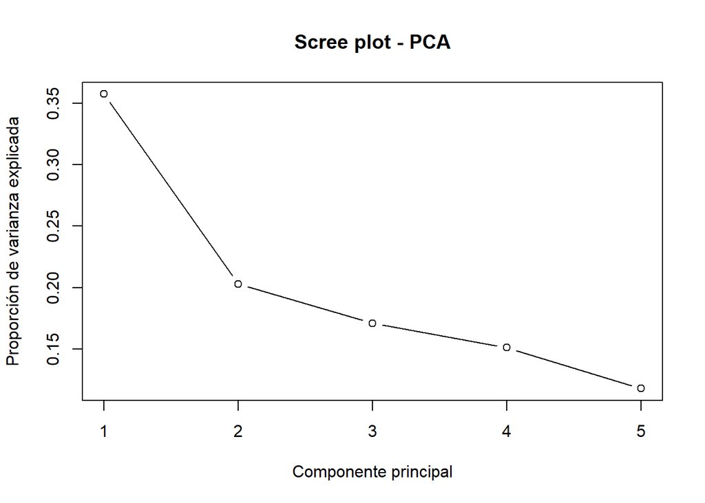

```r
var_scree <- pca_res$sdev^2 / sum(pca_res$sdev^2)

plot(var_scree,
type = "b",
xlab = "Componente principal",
ylab = "Proporción de varianza explicada",
main = "Scree plot - PCA")
```